# Decision Trees

clear your environment

```r
rm(list = ls(all=TRUE))
```

# C5.0 Trees

## Goal

- The goal of this activity is to predict whether a car is recommended for purchase, given various qualities of the car
- For this we analyze data where expert car analysts make recommendations regarding car purchase
- By analyzing their expert decision support system, we can gain interesting insights in the business oppurtunities available in the car market

## Reading & Understanding the Data

### Read the Data

Set up working directory and Load data

```r
path <- getwd()
setwd(path)

car_data <- read.csv("car_eval.csv")
```

### Understand the data

- Use the str(), summary(), head() and tail() functions to get the dimensions and types of attributes in the dataset
- The dataset has 1728 observations and 7 variables

```r
str(car_data)
```

```
## 'data.frame':    1728 obs. of  7 variables:
##  $ buying_price: Factor w/ 4 levels "high","low","med",..: 4 4 4 4 4 4 4 4 4 4 ...
##  $ maint_cost  : Factor w/ 4 levels "high","low","med",..: 4 4 4 4 4 4 4 4 4 4 ...
##  $ doors       : Factor w/ 4 levels "2","3","4","5more": 1 1 1 1 1 1 1 1 1 1 ...
##  $ persons     : Factor w/ 3 levels "2","4","more": 1 1 1 1 1 1 1 1 1 2 ...
##  $ lug_boot    : Factor w/ 3 levels "big","med","small": 3 3 3 2 2 2 1 1 1 3 ...
##  $ safety      : Factor w/ 3 levels "high","low","med": 2 3 1 2 3 1 2 3 1 2 ...
##  $ decision    : Factor w/ 2 levels "notRecommended",..: 1 1 1 1 1 1 1 1 1 1 ...
```

```r
summary(car_data)
```

```
##  buying_price maint_cost    doors     persons     lug_boot    safety
##  high :432    high :432   2    :432   2   :576   big  :576   high:576
##  low  :432    low  :432   3    :432   4   :576   med  :576   low :576
##  med  :432    med  :432   4    :432   more:576   small:576   med :576
##  vhigh:432    vhigh:432   5more:432
##            decision
##  notRecommended:1210
##  recommended   : 518
##
##
```

```r
head(car_data)
```

```
##   buying_price maint_cost doors persons lug_boot safety       decision
## 1        vhigh      vhigh     2       2    small    low notRecommended
## 2        vhigh      vhigh     2       2    small    med notRecommended
## 3        vhigh      vhigh     2       2    small   high notRecommended
## 4        vhigh      vhigh     2       2      med    low notRecommended
## 5        vhigh      vhigh     2       2      med    med notRecommended
## 6        vhigh      vhigh     2       2      med   high notRecommended
```

```r
tail(car_data)
```

```
##      buying_price maint_cost doors persons lug_boot safety       decision
## 1723          low        low 5more    more      med    low notRecommended
## 1724          low        low 5more    more      med    med    recommended
## 1725          low        low 5more    more      med   high    recommended
## 1726          low        low 5more    more      big    low notRecommended
## 1727          low        low 5more    more      big    med    recommended
## 1728          low        low 5more    more      big   high    recommended
```

### Data Description

- This dataset includes attributes that are involved while making the decision of purchasing a car.
- The goal here is analyze the data for recommending cars, using decision trees
- The dataset has the following attributes:

1 - buying_price : The cost of purchasing the car (categorical: 4 categories)

2 - maint_cost : The cost of maintaining the car (categorical: 4 categories)

3 - doors : Number of doors the car has (categorical: 4 categories)

4 - persons : Number of persons the car can accomodate (categorical: 3 categories)

5 - lug_boot: The size of the luggage boot available in the car (categorical: 3 categories)

6 - safety: The safety rating of the vehicle (categorical: 3 categories)

7 - decision: Expert recommendation given to the car (categorical: “recommended”, “notRecommended”)

## Data Pre-processing

### Verify Data Integrity

- missing values

```r
sum(is.na(car_data))
```

```
## [1] 0
```

- data types assigned to the variables in the dataset

```r
str(car_data)
```

```
## 'data.frame':    1728 obs. of  7 variables:
##  $ buying_price: Factor w/ 4 levels "high","low","med",..: 4 4 4 4 4 4 4 4 4 4 ...
##  $ maint_cost  : Factor w/ 4 levels "high","low","med",..: 4 4 4 4 4 4 4 4 4 4 ...
##  $ doors       : Factor w/ 4 levels "2","3","4","5more": 1 1 1 1 1 1 1 1 1 1 ...
##  $ persons     : Factor w/ 3 levels "2","4","more": 1 1 1 1 1 1 1 1 1 2 ...
##  $ lug_boot    : Factor w/ 3 levels "big","med","small": 3 3 3 2 2 2 1 1 1 3 ...
##  $ safety      : Factor w/ 3 levels "high","low","med": 2 3 1 2 3 1 2 3 1 2 ...
##  $ decision    : Factor w/ 2 levels "notRecommended",..: 1 1 1 1 1 1 1 1 1 1 ...
```

```r
lapply(car_data, table)
```

```
## $buying_price
##
##  high   low   med vhigh
##   432   432   432   432
##
## $maint_cost
##
##  high   low   med vhigh
##   432   432   432   432
##
## $doors
##
##     2     3     4 5more
##   432   432   432   432
##
## $persons
##
##    2    4 more
##  576  576  576
##
## $lug_boot
##
##   big   med small
##   576   576   576
##
## $safety
##
## high  low  med
##  576  576  576
##
## $decision
##
## notRecommended    recommended
##           1210            518
```

### Split the Data into train and test sets

```r
library(caret)
set.seed(007)

trainIndex <- createDataPartition(car_data$decision, p = .7, list = F)

train_data <- car_data[trainIndex, ]

test_data <- car_data[-trainIndex, ]
```

## Build a Decision Tree

### Model the tree

- We will be using Quinlan’s C5.0 decision tree algorithm implementation from the C50 package to build our decision tree

```r
library(C50)

#Tree based model
c5_tree <- C5.0(decision ~ . , train_data)

# Use the rules = T argument if you want to extract rules later from the model
#Rule based model
c5_rules <- C5.0(decision ~ . , train_data, rules = T)
```

### Variable Importance in trees

- Find the importance of each variable in the dataset using the c5imp() function
- The default metric “usage” in the c5imp function gives the percentage of data being split by using the attribute at that particular time. So variable used for splitting at the root node always has 100, and the variables at the leaf nodes might be close to 0 if there is no data remaining to classify

```r
C5imp(c5_tree, metric = "usage")
```

```
##              Overall
## persons       100.00
## safety         66.36
## buying_price   44.21
## lug_boot       31.16
## maint_cost     29.01
## doors          11.65
```

### Rules from trees

- Understand the summary of the returned c5.0 rule based and tree based models

```r
summary(c5_rules)
```

```
##
## Call:
## C5.0.formula(formula = decision ~ ., data = train_data, rules = T)
##
##
## C5.0 [Release 2.07 GPL Edition]      Tue Aug 06 14:53:47 2019
## -------------------------------
##
## Class specified by attribute `outcome'
##
## Read 1210 cases (7 attributes) from undefined.data
##
## Rules:
##
## Rule 1: (407, lift 1.4)
##  persons = 2
##  ->  class notRecommended  [0.998]
##
## Rule 2: (397, lift 1.4)
##  safety = low
##  ->  class notRecommended  [0.997]
##
## Rule 3: (161, lift 1.4)
##  buying_price in {high, vhigh}
##  maint_cost = vhigh
##  ->  class notRecommended  [0.994]
##
## Rule 4: (73, lift 1.4)
##  buying_price = vhigh
##  maint_cost = high
##  ->  class notRecommended  [0.987]
##
## Rule 5: (67, lift 1.4)
##  buying_price in {high, vhigh}
##  lug_boot = small
##  safety = med
##  ->  class notRecommended  [0.986]
##
## Rule 6: (33, lift 1.4)
##  maint_cost = vhigh
```

[output cut: 87 more lines]

```
##     838     9    (a): class notRecommended
##       1   362    (b): class recommended
##
##
##  Attribute usage:
##
##   74.55% safety
##   69.83% persons
##   48.35% maint_cost
##   46.20% buying_price
##   35.95% lug_boot
##   16.86% doors
##
##
## Time: 0.0 secs
```

### Plotting the tree

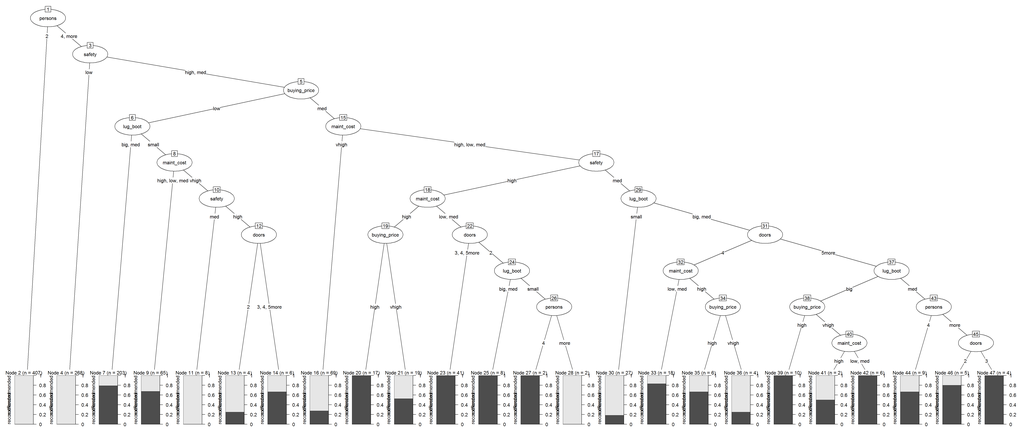

```r
plot(c5_tree)
```

## Evaluating the model

### Predictions on the test data

```r
preds <- predict(c5_tree, test_data)
```

Confusion Matrix

```r
library(caret)

confusionMatrix(preds, test_data$decision)
```

```
## Confusion Matrix and Statistics
##
##                 Reference
## Prediction       notRecommended recommended
##   notRecommended            347           1
##   recommended                16         154
##
##                Accuracy : 0.9672
##                  95% CI : (0.948, 0.9808)
##     No Information Rate : 0.7008
##     P-Value [Acc > NIR] : < 2.2e-16
##
##                   Kappa : 0.9239
##
##  Mcnemar's Test P-Value : 0.000685
##
##             Sensitivity : 0.9559
##             Specificity : 0.9935
##          Pos Pred Value : 0.9971
##          Neg Pred Value : 0.9059
##              Prevalence : 0.7008
##          Detection Rate : 0.6699
##    Detection Prevalence : 0.6718
##       Balanced Accuracy : 0.9747
##
##        'Positive' Class : notRecommended
##
```

# CART Trees

- The classification and regression trees use gini index in place of the gain ratio (based on information gain) used by the ID3 based algorithms, such as c4.5 and c5.0 *to do rgression use cart package

  Implementing CART on the previous dataset

```r
#Tree based model
library(rpart)
rpart_tree <- rpart(decision ~ . , data = train_data, method="class")
```

## Tree Explicability

- The variable importance can be accesssed using variable.importance from the rpart_tree list

```r
rpart_tree$variable.importance
```

```
##       safety      persons buying_price   maint_cost     lug_boot
##   178.842612   111.546981    68.335092    50.275161    28.982411
##        doors
##     6.328276
```

## Evaluating the model

### Predictions on the test data

```r
preds_rpart <- predict(rpart_tree, test_data, type="class")
```

confusion Matrix

```r
library(caret)

confusionMatrix(preds_rpart, test_data$decision)
```

```
## Confusion Matrix and Statistics
##
##                 Reference
## Prediction       notRecommended recommended
##   notRecommended            336           1
##   recommended                27         154
##
##                Accuracy : 0.9459
##                  95% CI : (0.9228, 0.9638)
##     No Information Rate : 0.7008
##     P-Value [Acc > NIR] : < 2.2e-16
##
##                   Kappa : 0.877
##
##  Mcnemar's Test P-Value : 2.306e-06
##
##             Sensitivity : 0.9256
##             Specificity : 0.9935
##          Pos Pred Value : 0.9970
##          Neg Pred Value : 0.8508
##              Prevalence : 0.7008
##          Detection Rate : 0.6486
##    Detection Prevalence : 0.6506
##       Balanced Accuracy : 0.9596
##
##        'Positive' Class : notRecommended
##
```

## Goal -CART for regression

- The goal of this activity is to predict the imbd score of a movie using a classification and regression tree (cart)

## Reading & Understanding the Data

### Read the Data

```r
mov_data <- read.csv("movie_data.csv", na.strings = "")
```

- Select only a subset of columns from the original data for this exercise

```r
movie_data <- mov_data[, names(mov_data) %in%
                         c("color", "num_critic_for_reviews", "duration", "director_facebook_likes",
                           "gross", "cast_total_facebook_likes", "num_user_for_reviews", "budget",
                           "movie_facebook_likes", "imdb_score")]
```

### Understand the data

- The dataset has 5043 observations and 10 variables after extracting only the important columns

```r
str(movie_data)
```

```
## 'data.frame':    5043 obs. of  10 variables:
##  $ color                    : Factor w/ 2 levels " Black and White",..: 2 2 2 2 NA 2 2 2 2 2 ...
##  $ num_critic_for_reviews   : int  723 302 602 813 NA 462 392 324 635 375 ...
##  $ duration                 : int  178 169 148 164 NA 132 156 100 141 153 ...
##  $ director_facebook_likes  : int  0 563 0 22000 131 475 0 15 0 282 ...
##  $ gross                    : int  760505847 309404152 200074175 448130642 NA 73058679 336530303 200807262 458991599 301956980 ...
##  $ cast_total_facebook_likes: int  4834 48350 11700 106759 143 1873 46055 2036 92000 58753 ...
##  $ num_user_for_reviews     : int  3054 1238 994 2701 NA 738 1902 387 1117 973 ...
##  $ budget                   : num  2.37e+08 3.00e+08 2.45e+08 2.50e+08 NA ...
##  $ imdb_score               : num  7.9 7.1 6.8 8.5 7.1 6.6 6.2 7.8 7.5 7.5 ...
##  $ movie_facebook_likes     : int  33000 0 85000 164000 0 24000 0 29000 118000 10000 ...
```

```r
summary(movie_data)
```

```
##               color      num_critic_for_reviews    duration
##   Black and White: 209   Min.   :  1.0          Min.   :  7.0
##  Color           :4815   1st Qu.: 50.0          1st Qu.: 93.0
##  NA's            :  19   Median :110.0          Median :103.0
##                          Mean   :140.2          Mean   :107.2
##                          3rd Qu.:195.0          3rd Qu.:118.0
##                          Max.   :813.0          Max.   :511.0
##                          NA's   :50             NA's   :15
##  director_facebook_likes     gross           cast_total_facebook_likes
##  Min.   :    0.0         Min.   :      162   Min.   :     0
##  1st Qu.:    7.0         1st Qu.:  5340988   1st Qu.:  1411
##  Median :   49.0         Median : 25517500   Median :  3090
##  Mean   :  686.5         Mean   : 48468408   Mean   :  9699
##  3rd Qu.:  194.5         3rd Qu.: 62309438   3rd Qu.: 13756
##  Max.   :23000.0         Max.   :760505847   Max.   :656730
##  NA's   :104             NA's   :884
##  num_user_for_reviews     budget            imdb_score
##  Min.   :   1.0       Min.   :2.180e+02   Min.   :1.600
##  1st Qu.:  65.0       1st Qu.:6.000e+06   1st Qu.:5.800
##  Median : 156.0       Median :2.000e+07   Median :6.600
##  Mean   : 272.8       Mean   :3.975e+07   Mean   :6.442
##  3rd Qu.: 326.0       3rd Qu.:4.500e+07   3rd Qu.:7.200
##  Max.   :5060.0       Max.   :1.222e+10   Max.   :9.500
##  NA's   :21           NA's   :492
##  movie_facebook_likes
##  Min.   :     0
##  1st Qu.:     0
##  Median :   166
##  Mean   :  7526
##  3rd Qu.:  3000
##  Max.   :349000
##
```

```r
head(movie_data)
```

```
##   color num_critic_for_reviews duration director_facebook_likes     gross
## 1 Color                    723      178                       0 760505847
## 2 Color                    302      169                     563 309404152
## 3 Color                    602      148                       0 200074175
## 4 Color                    813      164                   22000 448130642
## 5  <NA>                     NA       NA                     131        NA
## 6 Color                    462      132                     475  73058679
##   cast_total_facebook_likes num_user_for_reviews    budget imdb_score
## 1                      4834                 3054 237000000        7.9
## 2                     48350                 1238 300000000        7.1
## 3                     11700                  994 245000000        6.8
## 4                    106759                 2701 250000000        8.5
## 5                       143                   NA        NA        7.1
## 6                      1873                  738 263700000        6.6
##   movie_facebook_likes
## 1                33000
## 2                    0
## 3                85000
## 4               164000
## 5                    0
## 6                24000
```

```r
tail(movie_data)
```

```
##      color num_critic_for_reviews duration director_facebook_likes gross
## 5038 Color                     14       95                       0  4584
## 5039 Color                      1       87                       2    NA
## 5040 Color                     43       43                      NA    NA
## 5041 Color                     13       76                       0    NA
## 5042 Color                     14      100                       0 10443
## 5043 Color                     43       90                      16 85222
##      cast_total_facebook_likes num_user_for_reviews budget imdb_score
## 5038                       690                   14   9000        6.4
## 5039                      2283                    6     NA        7.7
## 5040                      1753                  359     NA        7.5
## 5041                         0                    3   1400        6.3
## 5042                      2386                    9     NA        6.3
## 5043                       163                   84   1100        6.6
##      movie_facebook_likes
## 5038                  413
## 5039                   84
## 5040                32000
## 5041                   16
## 5042                  660
## 5043                  456
```

## Data Pre-processing

### Verify Data Integrity

- missing values

```r
sum(is.na(movie_data))
```

```
## [1] 1585
```

- We shall impute the missing values after splitting the data into train/test
- Verify the data types assigned to the variables in the dataset

```r
str(movie_data)
```

```
## 'data.frame':    5043 obs. of  10 variables:
##  $ color                    : Factor w/ 2 levels " Black and White",..: 2 2 2 2 NA 2 2 2 2 2 ...
##  $ num_critic_for_reviews   : int  723 302 602 813 NA 462 392 324 635 375 ...
##  $ duration                 : int  178 169 148 164 NA 132 156 100 141 153 ...
##  $ director_facebook_likes  : int  0 563 0 22000 131 475 0 15 0 282 ...
##  $ gross                    : int  760505847 309404152 200074175 448130642 NA 73058679 336530303 200807262 458991599 301956980 ...
##  $ cast_total_facebook_likes: int  4834 48350 11700 106759 143 1873 46055 2036 92000 58753 ...
##  $ num_user_for_reviews     : int  3054 1238 994 2701 NA 738 1902 387 1117 973 ...
##  $ budget                   : num  2.37e+08 3.00e+08 2.45e+08 2.50e+08 NA ...
##  $ imdb_score               : num  7.9 7.1 6.8 8.5 7.1 6.6 6.2 7.8 7.5 7.5 ...
##  $ movie_facebook_likes     : int  33000 0 85000 164000 0 24000 0 29000 118000 10000 ...
```

- The data types of the variables were properly assigned

### Split the Data into train and test sets

- As this is a regression problem, we use only random sampling for the train/test split (70/30)

```r
set.seed(1234)

train_rows <- sample(1:nrow(movie_data), 0.7*nrow(movie_data))

train_reg <- movie_data[train_rows, ]

test_reg <- movie_data[-train_rows, ]
```

### Impute the missing values

- Let’s first impute the missing values in the training data

```r
library(DMwR)
train_reg <- knnImputation(train_reg, k = 5, scale = T)
```

```r
test_reg <- knnImputation(test_reg, 5, scale = T, distData = train_reg)
```

## Build a Regression Tree

### Model the tree

- We will be using the cart based decision tree algorithm implementation from the rpart package to build our regression tree

```r
library(rpart)

reg_tree <- rpart(imdb_score ~ ., train_reg)


printcp(reg_tree)
```

```
##
## Regression tree:
## rpart(formula = imdb_score ~ ., data = train_reg)
##
## Variables actually used in tree construction:
## [1] duration               gross                  movie_facebook_likes
## [4] num_critic_for_reviews
##
## Root node error: 4528.9/3530 = 1.283
##
## n= 3530
##
##         CP nsplit rel error  xerror     xstd
## 1 0.095778      0   1.00000 1.00036 0.029015
## 2 0.048966      1   0.90422 0.91784 0.026874
## 3 0.028695      2   0.85526 0.86107 0.025771
## 4 0.021922      5   0.76917 0.79457 0.025483
## 5 0.010808      6   0.74725 0.76556 0.024801
## 6 0.010000      7   0.73644 0.75677 0.024493
```

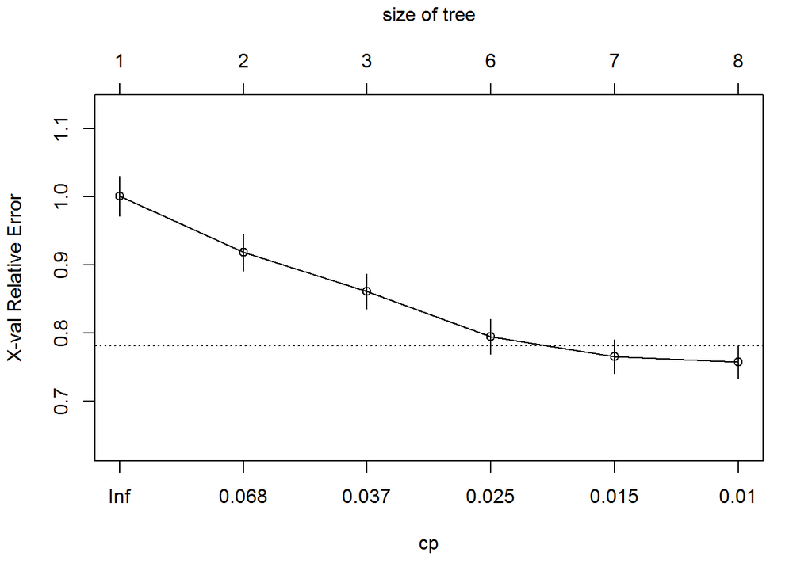

```r
plotcp(reg_tree)
```

### Experimenting with complexity parameter(cp).#cp is used to prune the tree to avoid overfitting

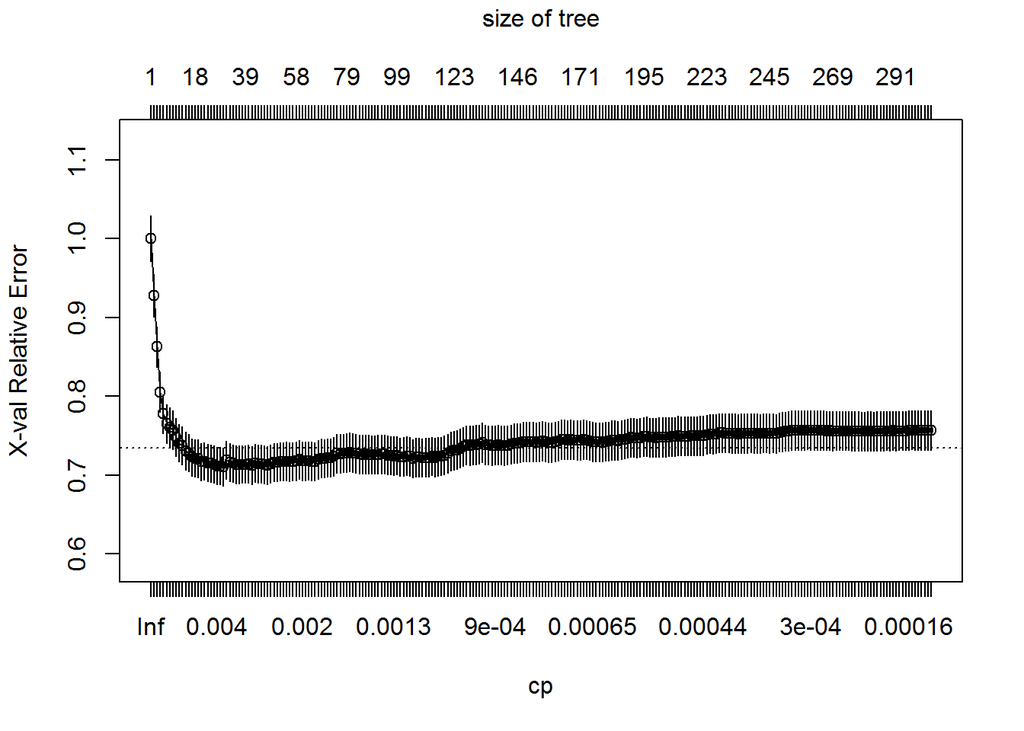

```r
reg_tree1 <- rpart(imdb_score ~ ., train_reg, control = rpart.control(cp = 0.0001))

plotcp(reg_tree1)
```

### Tree Explicability

- The variable importance can accessed accessing variable.importance from the reg.tree list

```r
reg_tree$variable.importance
```

```
##                  duration      movie_facebook_likes
##                 558.98501                 465.56265
##                     gross    num_critic_for_reviews
##                 234.54380                 208.49409
##      num_user_for_reviews                    budget
##                 132.53482                  74.26326
##   director_facebook_likes cast_total_facebook_likes
##                  39.49022                  36.49390
```

- We can plot the regression tree using the rpart.plot() function from the rpart.plot package

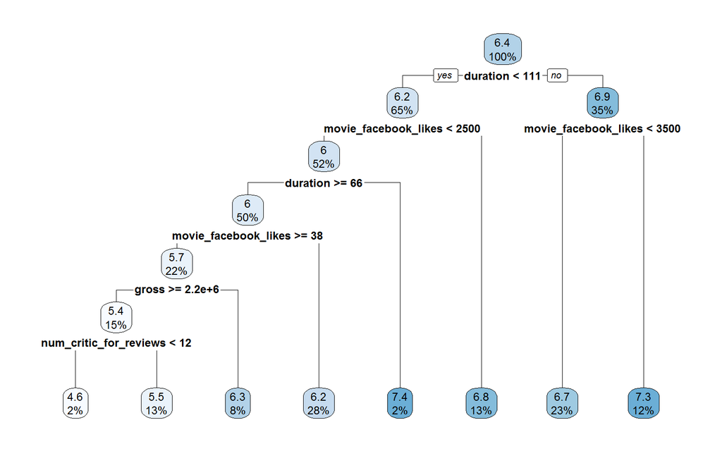

```r
library(rpart.plot)

rpart.plot(reg_tree)
```

## Plotting the second tree with minimum cp

```r
rpart.plot(reg_tree1)
```

[figure not shown]

## Evaluation on Test Data

```r
preds_reg <- predict(reg_tree, test_reg)

preds_reg1 <- predict(reg_tree1, test_reg) #with the changed cp value
```

```r
library(DMwR)

regr.eval(test_reg$imdb_score, preds_reg)
```

```
##       mae       mse      rmse      mape
## 0.7611496 0.9745631 0.9871996 0.1330453
```

```r
regr.eval(test_reg$imdb_score, preds_reg1) #with the changed cp value
```

```
##       mae       mse      rmse      mape
## 0.7353777 0.9976940 0.9988463 0.1290411
```